# 11-02. 시계열 (시간대 다루기, 기간과 기간연산, 리샘플링, 빈도 변환, 이동창 함수)

```python
import pandas as pd
import numpy as np
import matplotlib.pyplot as plt
```

### 시간대 다루기

- 국제표준시 (UTC)

```python
import pytz
```

```python
pytz.common_timezones[-5:]
```

```
['US/Eastern', 'US/Hawaii', 'US/Mountain', 'US/Pacific', 'UTC']
```

### `pytz.timezone()`

```python
tz = pytz.timezone('America/New_York')
tz
```

```
<DstTzInfo 'America/New_York' LMT-1 day, 19:04:00 STD>
```

### 시간대 지역화, 시간대 변환

```python
rng = pd.date_range('3/9/2012 9:30', periods = 6, freq = 'D')
ts = pd.Series(np.random.randn(len(rng)), index = rng)
```

```python
print(ts.index.tz)
```

```
None
```

### 시간대를 지정해서 날짜 범위 생성

```python
pd.date_range('3/9/2012 9:30', periods = 10, freq = 'D', tz = 'UTC')
```

```
DatetimeIndex(['2012-03-09 09:30:00+00:00', '2012-03-10 09:30:00+00:00',
               '2012-03-11 09:30:00+00:00', '2012-03-12 09:30:00+00:00',
               '2012-03-13 09:30:00+00:00', '2012-03-14 09:30:00+00:00',
               '2012-03-15 09:30:00+00:00', '2012-03-16 09:30:00+00:00',
               '2012-03-17 09:30:00+00:00', '2012-03-18 09:30:00+00:00'],
              dtype='datetime64[ns, UTC]', freq='D')
```

### `ts.tz_localize('UTC')` : 지역화 시간으로 변환

```python
ts_utc = ts.tz_localize('UTC')
```

```python
ts_utc
```

```
2012-03-09 09:30:00+00:00   -1.175048
2012-03-10 09:30:00+00:00    0.904160
2012-03-11 09:30:00+00:00   -0.920414
2012-03-12 09:30:00+00:00   -0.601984
2012-03-13 09:30:00+00:00    1.570478
2012-03-14 09:30:00+00:00    0.568905
Freq: D, dtype: float64
```

### `.tz_convert('시간대')` : 다른 시간대로 변환

```python
ts_utc.tz_convert('America/New_York')
```

```
2012-03-09 04:30:00-05:00   -1.175048
2012-03-10 04:30:00-05:00    0.904160
2012-03-11 05:30:00-04:00   -0.920414
2012-03-12 05:30:00-04:00   -0.601984
2012-03-13 05:30:00-04:00    1.570478
2012-03-14 05:30:00-04:00    0.568905
Freq: D, dtype: float64
```

- `tz_localize`와 `tz_convert`는 모두 DatetimeIndex의 인스턴스 메서드

```python
ts.index.tz_localize('Asia/Seoul')
```

```
DatetimeIndex(['2012-03-09 09:30:00+09:00', '2012-03-10 09:30:00+09:00',
               '2012-03-11 09:30:00+09:00', '2012-03-12 09:30:00+09:00',
               '2012-03-13 09:30:00+09:00', '2012-03-14 09:30:00+09:00'],
              dtype='datetime64[ns, Asia/Seoul]', freq=None)
```

### 시간대를 고려하여 Timestamp 객체 다루기

```python
stamp = pd.Timestamp('2011-03-12 04:00')
stamp_utc = stamp.tz_localize('utc')
stamp_utc.tz_convert('America/New_York')
```

```
Timestamp('2011-03-11 23:00:00-0500', tz='America/New_York')
```

- Timestamp 객체를 생성할 대, 시간대를 직접 넘겨주는 것도 가능

```python
stamp_moscow = pd.Timestamp('2011-03-12 04:00', tz = 'Europe/Moscow')
stamp_moscow
```

```
Timestamp('2011-03-12 04:00:00+0300', tz='Europe/Moscow')
```

- **시간대를 고려한 Timestamp 객체는 내부적으로 UTC 타임스탬프 값을 유닉스 에포크 (1970-01-01)부터 현재까지의 나노초로 저장**

```python
stamp_utc.value
```

```
1299902400000000000
```

```python
stamp_utc.tz_convert('America/New_York').value
```

```
1299902400000000000
```

```python
from pandas.tseries.offsets import Hour
```

```python
stamp = pd.Timestamp('2012-03-12 01:30', tz = 'US/Eastern')
stamp, stamp + Hour()
```

```
(Timestamp('2012-03-12 01:30:00-0400', tz='US/Eastern'),
 Timestamp('2012-03-12 02:30:00-0400', tz='US/Eastern'))
```

```python
stamp = pd.Timestamp('2012-11-04 00:30', tz = 'US/Eastern')
stamp, stamp + 2 * Hour()
```

```
(Timestamp('2012-11-04 00:30:00-0400', tz='US/Eastern'),
 Timestamp('2012-11-04 01:30:00-0500', tz='US/Eastern'))
```

### 다른 시간대 간의 연산

```python
rng = pd.date_range('3/7/2012 9:30', periods = 10, freq = 'B')
ts = pd.Series(np.random.randn(len(rng)), index = rng)
```

```python
ts1 = ts[:7].tz_localize('Europe/London')
ts2 = ts1[2:].tz_convert('Europe/Moscow')
result = ts1 + ts2
result, result.index
```

```
(2012-03-07 09:30:00+00:00         NaN
 2012-03-08 09:30:00+00:00         NaN
 2012-03-09 09:30:00+00:00    0.375890
 2012-03-12 09:30:00+00:00    2.682776
 2012-03-13 09:30:00+00:00   -1.573242
 2012-03-14 09:30:00+00:00    0.140010
 2012-03-15 09:30:00+00:00    1.247985
 dtype: float64,
 DatetimeIndex(['2012-03-07 09:30:00+00:00', '2012-03-08 09:30:00+00:00',
                '2012-03-09 09:30:00+00:00', '2012-03-12 09:30:00+00:00',
                '2012-03-13 09:30:00+00:00', '2012-03-14 09:30:00+00:00',
                '2012-03-15 09:30:00+00:00'],
               dtype='datetime64[ns, UTC]', freq=None))
```

### 기간과 기간 연산

- 며칠, 몇 개월, 몇 분기, 몇 해 같은 기간은 Period 클래스로 표현할 수 있다

### `pd.Period()`

```python
p = pd.Period(2007, freq = 'A-DEC')
p
```

```
Period('2007', 'A-DEC')
```

```python
p + 5, p - 2
```

```
(Period('2012', 'A-DEC'), Period('2005', 'A-DEC'))
```

- **만약 두 기간이 같은 빈도를 가진다면, 두 기간의 차는 둘 사이의 간격이 된다**

```python
pd.Period('2014', freq = 'A-DEC') - p
```

```
<7 * YearEnds: month=12>
```

### `pd.period_range(start, end, freq)` : 기간 범위 생성

```python
rng = pd.period_range('2000-01-01', '2000-06-30', freq = 'M')
rng
```

```
PeriodIndex(['2000-01', '2000-02', '2000-03', '2000-04', '2000-05', '2000-06'], dtype='period[M]')
```

```python
pd.Series(np.random.randn(6), index = rng)
```

```
2000-01    0.002284
2000-02   -0.685965
2000-03    0.310490
2000-04   -0.084973
2000-05    0.174062
2000-06    0.700680
Freq: M, dtype: float64
```

### `pd.PeriodIndex(values, freq)`

```python
values = ['2001Q3', '2002Q2', '2003Q1']
index = pd.PeriodIndex(values, freq = 'Q-DEC')
index
```

```
PeriodIndex(['2001Q3', '2002Q2', '2003Q1'], dtype='period[Q-DEC]')
```

### `period.asfreq('단위', how)`

```python
p = pd.Period('2007', freq = 'A-DEC')
p, p.asfreq('M', how = 'start'), p.asfreq('M', how = 'end')
```

```
(Period('2007', 'A-DEC'), Period('2007-01', 'M'), Period('2007-12', 'M'))
```

```python
p = pd.Period('2007', freq = 'A-JUN')
p, p.asfreq('M', 'start'), p.asfreq('M', 'end')
```

```
(Period('2007', 'A-JUN'), Period('2006-07', 'M'), Period('2007-06', 'M'))
```

- **빈도가 상위 단계에서 하뒤 단계로 변환되는 경우, 상위 기간은 하위 기간이 어디에 속했는지에 따라 결정**
- A-JUN 빈도일 경우, 2007년 8월은 실제로 2008년 기간에 속하게 된다

```python
p = pd.Period('Aug-2007', 'M')
p.asfreq('A-JUN')
```

```
Period('2008', 'A-JUN')
```

```python
rng = pd.period_range('2006', '2009', freq = 'A-DEC')
ts = pd.Series(np.random.randn(len(rng)), index = rng)
ts, ts.asfreq('M', how = 'start'), ts.asfreq('B', how = 'end')
```

```
(2006    1.206541
 2007   -0.694560
 2008   -0.658091
 2009   -0.278462
 Freq: A-DEC, dtype: float64,
 2006-01    1.206541
 2007-01   -0.694560
 2008-01   -0.658091
 2009-01   -0.278462
 Freq: M, dtype: float64,
 2006-12-29    1.206541
 2007-12-31   -0.694560
 2008-12-31   -0.658091
 2009-12-31   -0.278462
 Freq: B, dtype: float64)
```

### 분기 빈도

- 회계연도 마감이 1월인 경우라면 2012Q4는 11월부터 1월까지가 되고, 일간 빈도로 검사 가능

```python
p = pd.Period('2012Q4', freq = 'Q-JAN')
p, p.asfreq('D', 'start'), p.asfreq('D', 'end')
```

```
(Period('2012Q4', 'Q-JAN'),
 Period('2011-11-01', 'D'),
 Period('2012-01-31', 'D'))
```

```python
p4pm = (p.asfreq('B', 'e') - 1).asfreq('T', 's') + 16 * 60
p4pm, p4pm.to_timestamp()
```

```
(Period('2012-01-30 16:00', 'T'), Timestamp('2012-01-30 16:00:00'))
```

```python
rng = pd.period_range('2011Q3', '2012Q4', freq = 'Q-JAN')
ts = pd.Series(np.arange(len(rng)), index = rng)
ts
```

```
2011Q3    0
2011Q4    1
2012Q1    2
2012Q2    3
2012Q3    4
2012Q4    5
Freq: Q-JAN, dtype: int32
```

### `to_timestamp()` : Timestamp형으로 변환

```python
new_rng = (rng.asfreq('B', 'e') - 1).asfreq('T', 's') + 16 * 60
ts.index = new_rng.to_timestamp()
ts
```

```
2010-10-28 16:00:00    0
2011-01-28 16:00:00    1
2011-04-28 16:00:00    2
2011-07-28 16:00:00    3
2011-10-28 16:00:00    4
2012-01-30 16:00:00    5
dtype: int32
```

### 타임스탬프와 기간 서로 변환

### `to_period()` : Period으로 변환

```python
rng = pd.date_range('2000-01-01', periods = 3, freq='M')
ts = pd.Series(np.random.randn(3), index = rng)
ts
```

```
2000-01-31    0.352133
2000-02-29    0.559056
2000-03-31   -0.334444
Freq: M, dtype: float64
```

```python
pts = ts.to_period()
pts
```

```
2000-01    0.352133
2000-02    0.559056
2000-03   -0.334444
Freq: M, dtype: float64
```

- PeriodIndex의 빈도는 기본적으로 타임스탬프 값을 통해 추론되지만, 원하는 빈도를 직접 지정할 수도 있다

```python
rng = pd.date_range('1/29/2000', periods = 6, freq = 'D')
ts2 = pd.Series(np.random.randn(6), index = rng)
ts2
```

```
2000-01-29    1.161404
2000-01-30   -1.780627
2000-01-31   -0.513611
2000-02-01   -2.329299
2000-02-02   -0.614862
2000-02-03   -0.918390
Freq: D, dtype: float64
```

```python
ts2.to_period('M')
```

```
2000-01    1.161404
2000-01   -1.780627
2000-01   -0.513611
2000-02   -2.329299
2000-02   -0.614862
2000-02   -0.918390
Freq: M, dtype: float64
```

```python
pts = ts2.to_period()
pts
```

```
2000-01-29    1.161404
2000-01-30   -1.780627
2000-01-31   -0.513611
2000-02-01   -2.329299
2000-02-02   -0.614862
2000-02-03   -0.918390
Freq: D, dtype: float64
```

```python
pts.to_timestamp(how = 'end')
```

```
2000-01-29 23:59:59.999999999    1.161404
2000-01-30 23:59:59.999999999   -1.780627
2000-01-31 23:59:59.999999999   -0.513611
2000-02-01 23:59:59.999999999   -2.329299
2000-02-02 23:59:59.999999999   -0.614862
2000-02-03 23:59:59.999999999   -0.918390
Freq: D, dtype: float64
```

### 배열로 PeriodIndex 생성

```python
data = pd.read_csv("examples/macrodata.csv")
```

```python
data.head(5)
```

|  | year | quarter | realgdp | realcons | realinv | realgovt | realdpi | cpi | m1 | tbilrate | unemp | pop | infl | realint |
| --- | --- | --- | --- | --- | --- | --- | --- | --- | --- | --- | --- | --- | --- | --- |
| 0 | 1959.0 | 1.0 | 2710.349 | 1707.4 | 286.898 | 470.045 | 1886.9 | 28.98 | 139.7 | 2.82 | 5.8 | 177.146 | 0.00 | 0.00 |
| 1 | 1959.0 | 2.0 | 2778.801 | 1733.7 | 310.859 | 481.301 | 1919.7 | 29.15 | 141.7 | 3.08 | 5.1 | 177.830 | 2.34 | 0.74 |
| 2 | 1959.0 | 3.0 | 2775.488 | 1751.8 | 289.226 | 491.260 | 1916.4 | 29.35 | 140.5 | 3.82 | 5.3 | 178.657 | 2.74 | 1.09 |
| 3 | 1959.0 | 4.0 | 2785.204 | 1753.7 | 299.356 | 484.052 | 1931.3 | 29.37 | 140.0 | 4.33 | 5.6 | 179.386 | 0.27 | 4.06 |
| 4 | 1960.0 | 1.0 | 2847.699 | 1770.5 | 331.722 | 462.199 | 1955.5 | 29.54 | 139.6 | 3.50 | 5.2 | 180.007 | 2.31 | 1.19 |

```python
data.year.head()
data.quarter.head()
```

```
0    1.0
1    2.0
2    3.0
3    4.0
4    1.0
Name: quarter, dtype: float64
```

### `pd.PeriodIndex(year, quarter, freq)`

```python
index = pd.PeriodIndex(year = data.year, quarter = data.quarter,
                       freq = 'Q-DEC')
index[:5]
```

```
PeriodIndex(['1959Q1', '1959Q2', '1959Q3', '1959Q4', '1960Q1'], dtype='period[Q-DEC]')
```

```python
data.index = index
data.infl.head()
```

```
1959Q1    0.00
1959Q2    2.34
1959Q3    2.74
1959Q4    0.27
1960Q1    2.31
Freq: Q-DEC, Name: infl, dtype: float64
```

### 리샘플링과 빈도 변환

- 리샘플링 : 시계열의 빈도를 변환하는 과정
- 다운샘플링 : 상위 빈도의 데이터를 하위 빈도로 집계 <=> 업샘플링

### `.resample(freq, kind, ...)` : 빈도 변환과 관련된 모든 작업에서 사용, groupby와 비슷한 기능

- resample을 호출해서 데이터를 그룹 짓고 요약함수 적용

#### resample 메서드 인자

[output not shown]

```python
rng = pd.date_range('2000-01-01', periods = 100, freq = 'D')
ts = pd.Series(np.random.randn(len(rng)), index = rng)
ts.head()
```

```
2000-01-01    0.498174
2000-01-02    0.732057
2000-01-03    0.359329
2000-01-04   -1.600624
2000-01-05   -0.416005
Freq: D, dtype: float64
```

```python
ts.resample('M').mean()
```

```
2000-01-31    0.075607
2000-02-29    0.246911
2000-03-31    0.048972
2000-04-30   -0.340432
Freq: M, dtype: float64
```

```python
ts.resample('M', kind = 'period').mean()
```

```
2000-01    0.075607
2000-02    0.246911
2000-03    0.048972
2000-04   -0.340432
Freq: M, dtype: float64
```

### 다운샘플링

- 예를 들어 'M'이나 'BM'같은 월간 빈도로 변환하려면, 데이터를 월 간격으로 나눠야 한다.
- 각 간격은 한쪽이 열려 있게 되는데, 이 말은 하나의 간격에서 양끝 중 한쪽만 포함

#### resample을 사용해서 데이터를 다운샘플링할 때

1. 각 간격의 양끝 중에서 어느 쪽을 닫을 것인가
2. 집계하려는 구간의 라벨을 간격의 시작으로 할지 끝으로 할지 여부

```python
rng = pd.date_range('2000-01-01', periods = 12, freq = 'T')
ts = pd.Series(np.arange(12), index = rng)
ts.head()
```

```
2000-01-01 00:00:00    0
2000-01-01 00:01:00    1
2000-01-01 00:02:00    2
2000-01-01 00:03:00    3
2000-01-01 00:04:00    4
Freq: T, dtype: int32
```

- 5분 단위로 묶어서 각 그룹의 합을 집계
- **기본적으로 시작값을 그룹의 왼쪽에 포함시키므로 00:00의 값은 첫 번재 그룹의 00:00부터 00:05까지의 합을 집계**

```python
ts.resample('5min', closed = 'right').sum()
```

```
1999-12-31 23:55:00     0
2000-01-01 00:00:00    15
2000-01-01 00:05:00    40
2000-01-01 00:10:00    11
Freq: 5T, dtype: int32
```

```python
ts.resample('5min', closed = 'left').sum()
```

```
2000-01-01 00:00:00    10
2000-01-01 00:05:00    35
2000-01-01 00:10:00    21
Freq: 5T, dtype: int32
```

- **`label = 'right'`를 넘겨서 각 그룹의 오른쪽 값을 라벨로 사용**

```python
ts.resample('5min', closed = 'right', label = 'right').sum()
```

```
2000-01-01 00:00:00     0
2000-01-01 00:05:00    15
2000-01-01 00:10:00    40
2000-01-01 00:15:00    11
Freq: 5T, dtype: int32
```

- 반환된 결과의 인덱스를 특정 크기만큼 이동시키고 싶은 경우, **즉 그룹의 오른쪽 끝에서 1초를 빼서 타임스탬프가 참조하는 간격을 좀 더 명확히 보여주고 싶은 경우**에는 loffset 메서드에 문자열이나 날짜 오프셋을 넘기면 된다

```python
ts.resample('5min',
            closed = 'right',
            label = 'right',
            loffset = '-1s').sum()
```

```
1999-12-31 23:59:59     0
2000-01-01 00:04:59    15
2000-01-01 00:09:59    40
2000-01-01 00:14:59    11
Freq: 5T, dtype: int32
```

### OHLC 리샘플링

- 시가 (Open), 고가 (High), 저가 (Low), 종가 (Close) ### `.ohlc()`

```python
ts.resample('5min').ohlc()
```

|  | open | high | low | close |
| --- | --- | --- | --- | --- |
| 2000-01-01 00:00:00 | 0 | 4 | 0 | 4 |
| 2000-01-01 00:05:00 | 5 | 9 | 5 | 9 |
| 2000-01-01 00:10:00 | 10 | 11 | 10 | 11 |

### 업샘플링과 보간

```python
frame = pd.DataFrame(np.random.randn(2, 4),
                     index = pd.date_range('1/1/2000', periods = 2,
                                         freq = 'W-WED'),
                     columns=['Colorado', 'Texas', 'New York', 'Ohio'])
frame
```

|  | Colorado | Texas | New York | Ohio |
| --- | --- | --- | --- | --- |
| 2000-01-05 | 0.560290 | 0.770440 | 0.868617 | 0.453888 |
| 2000-01-12 | -0.559734 | 0.411329 | 0.367482 | 0.174968 |

```python
df_daily = frame.resample('D').asfreq()
df_daily
```

|  | Colorado | Texas | New York | Ohio |
| --- | --- | --- | --- | --- |
| 2000-01-05 | 0.560290 | 0.770440 | 0.868617 | 0.453888 |
| 2000-01-06 | NaN | NaN | NaN | NaN |
| 2000-01-07 | NaN | NaN | NaN | NaN |
| 2000-01-08 | NaN | NaN | NaN | NaN |
| 2000-01-09 | NaN | NaN | NaN | NaN |
| 2000-01-10 | NaN | NaN | NaN | NaN |
| 2000-01-11 | NaN | NaN | NaN | NaN |
| 2000-01-12 | -0.559734 | 0.411329 | 0.367482 | 0.174968 |

- 수요일이 아닌 요일에는 이전 값을 채워서 보간 수행

```python
frame.resample('D').ffill()
```

|  | Colorado | Texas | New York | Ohio |
| --- | --- | --- | --- | --- |
| 2000-01-05 | 0.560290 | 0.770440 | 0.868617 | 0.453888 |
| 2000-01-06 | 0.560290 | 0.770440 | 0.868617 | 0.453888 |
| 2000-01-07 | 0.560290 | 0.770440 | 0.868617 | 0.453888 |
| 2000-01-08 | 0.560290 | 0.770440 | 0.868617 | 0.453888 |
| 2000-01-09 | 0.560290 | 0.770440 | 0.868617 | 0.453888 |
| 2000-01-10 | 0.560290 | 0.770440 | 0.868617 | 0.453888 |
| 2000-01-11 | 0.560290 | 0.770440 | 0.868617 | 0.453888 |
| 2000-01-12 | -0.559734 | 0.411329 | 0.367482 | 0.174968 |

- **`limit = 2`옵션을 사용해서 보간법을 적용할 범위를 지정**

```python
frame.resample('D').ffill(limit = 2)
```

|  | Colorado | Texas | New York | Ohio |
| --- | --- | --- | --- | --- |
| 2000-01-05 | 0.560290 | 0.770440 | 0.868617 | 0.453888 |
| 2000-01-06 | 0.560290 | 0.770440 | 0.868617 | 0.453888 |
| 2000-01-07 | 0.560290 | 0.770440 | 0.868617 | 0.453888 |
| 2000-01-08 | NaN | NaN | NaN | NaN |
| 2000-01-09 | NaN | NaN | NaN | NaN |
| 2000-01-10 | NaN | NaN | NaN | NaN |
| 2000-01-11 | NaN | NaN | NaN | NaN |
| 2000-01-12 | -0.559734 | 0.411329 | 0.367482 | 0.174968 |

- 새로운 날짜 인덱스

```python
frame.resample('W-THU').ffill()
```

|  | Colorado | Texas | New York | Ohio |
| --- | --- | --- | --- | --- |
| 2000-01-06 | 0.560290 | 0.770440 | 0.868617 | 0.453888 |
| 2000-01-13 | -0.559734 | 0.411329 | 0.367482 | 0.174968 |

### 기간 리샘플링

```python
frame = pd.DataFrame(np.random.randn(24, 4),
                     index = pd.period_range('1-2000', '12-2001',
                                           freq = 'M'),
                     columns = ['Colorado', 'Texas', 'New York', 'Ohio'])
frame.head()
```

|  | Colorado | Texas | New York | Ohio |
| --- | --- | --- | --- | --- |
| 2000-01 | -0.512002 | 0.694438 | 0.582362 | 0.511349 |
| 2000-02 | -1.289150 | -0.279302 | -0.046492 | 0.390975 |
| 2000-03 | -1.623326 | -0.421571 | 1.524587 | -1.210371 |
| 2000-04 | 0.176965 | 1.165209 | -0.465936 | 0.698327 |
| 2000-05 | 0.465602 | 1.678531 | 0.100184 | -1.015446 |

```python
annual_frame = frame.resample('A-DEC').mean()
annual_frame
```

|  | Colorado | Texas | New York | Ohio |
| --- | --- | --- | --- | --- |
| 2000 | -0.417475 | -0.185738 | -0.074308 | 0.282473 |
| 2001 | -0.050174 | 0.125075 | -0.239899 | -0.751633 |

```python
# Q-DEC: 12월을 연도마감으로 하는 분기 주기
annual_frame.resample('Q-DEC').ffill()
```

|  | Colorado | Texas | New York | Ohio |
| --- | --- | --- | --- | --- |
| 2000Q1 | -0.417475 | -0.185738 | -0.074308 | 0.282473 |
| 2000Q2 | -0.417475 | -0.185738 | -0.074308 | 0.282473 |
| 2000Q3 | -0.417475 | -0.185738 | -0.074308 | 0.282473 |
| 2000Q4 | -0.417475 | -0.185738 | -0.074308 | 0.282473 |
| 2001Q1 | -0.050174 | 0.125075 | -0.239899 | -0.751633 |
| 2001Q2 | -0.050174 | 0.125075 | -0.239899 | -0.751633 |
| 2001Q3 | -0.050174 | 0.125075 | -0.239899 | -0.751633 |
| 2001Q4 | -0.050174 | 0.125075 | -0.239899 | -0.751633 |

```python
annual_frame.resample('Q-DEC', convention = 'end').ffill()
```

|  | Colorado | Texas | New York | Ohio |
| --- | --- | --- | --- | --- |
| 2000Q4 | -0.417475 | -0.185738 | -0.074308 | 0.282473 |
| 2001Q1 | -0.417475 | -0.185738 | -0.074308 | 0.282473 |
| 2001Q2 | -0.417475 | -0.185738 | -0.074308 | 0.282473 |
| 2001Q3 | -0.417475 | -0.185738 | -0.074308 | 0.282473 |
| 2001Q4 | -0.050174 | 0.125075 | -0.239899 | -0.751633 |

- **기간의 업샘플링과 다운샘플링은 좀 더 엄격**
1. 다운샘플링의 경우 대상 빈도는 반드시 원본 빈도의 **하위 기간**이어야 한다.
2. 업샘플링의 경우 대상 빈도는 반드시 원본 빈도의 **상위 기간**이어야 한다.

### 이동창 함수

```python
close_px_all = pd.read_csv('examples/stock_px_2.csv',
                           parse_dates = True, index_col = 0)
```

```python
close_px = close_px_all[['AAPL', 'MSFT', 'XOM']]
```

```python
close_px_all.head()
```

|  | AAPL | MSFT | XOM | SPX |
| --- | --- | --- | --- | --- |
| 2003-01-02 | 7.40 | 21.11 | 29.22 | 909.03 |
| 2003-01-03 | 7.45 | 21.14 | 29.24 | 908.59 |
| 2003-01-06 | 7.45 | 21.52 | 29.96 | 929.01 |
| 2003-01-07 | 7.43 | 21.93 | 28.95 | 922.93 |
| 2003-01-08 | 7.28 | 21.31 | 28.83 | 909.93 |

- 영업일 빈도로 리샘플링

```python
close_px = close_px.resample('B').ffill()
```

```python
close_px.head()
```

|  | AAPL | MSFT | XOM |
| --- | --- | --- | --- |
| 2003-01-02 | 7.40 | 21.11 | 29.22 |
| 2003-01-03 | 7.45 | 21.14 | 29.24 |
| 2003-01-06 | 7.45 | 21.52 | 29.96 |
| 2003-01-07 | 7.43 | 21.93 | 28.95 |
| 2003-01-08 | 7.28 | 21.31 | 28.83 |

### resample이나 groupby와 유사하게 작동하는 rolling 연산

### `.rolling(n)`

- **AAPL 주가의 250일 이동평균**

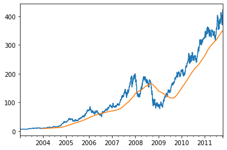

```python
plt.figure()
close_px.AAPL.plot()
close_px.AAPL.rolling(250).mean().plot()
plt.show()
```

```python
appl_std250 = close_px.AAPL.rolling(250, min_periods = 10).std()
appl_std250[5:12]
```

```
2003-01-09         NaN
2003-01-10         NaN
2003-01-13         NaN
2003-01-14         NaN
2003-01-15    0.077496
2003-01-16    0.074760
2003-01-17    0.112368
Freq: B, Name: AAPL, dtype: float64
```

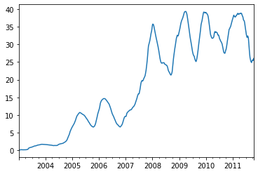

```python
plt.figure()
appl_std250.plot()
plt.show()
```

### 확장창 평균 (expanding window mean) : 창 (window)의 크기가 시계열의 전체 크기가 될 대까지 점점 창의 크기를 확장

### `.expanding()`

```python
expanding_mean = appl_std250.expanding().mean()
```

- 주가의 60일 이동평균 (Y축 로그스케일)

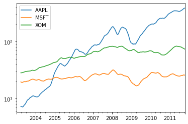

```python
plt.figure()
close_px.rolling(60).mean().plot(logy = True)
plt.show()
```

- **rolling함수는 고정 크기의 기간 지정 문자열을 넘겨서 호출 가능**

```python
close_px.rolling('20D').mean().head()
```

|  | AAPL | MSFT | XOM |
| --- | --- | --- | --- |
| 2003-01-02 | 7.400000 | 21.110000 | 29.220000 |
| 2003-01-03 | 7.425000 | 21.125000 | 29.230000 |
| 2003-01-06 | 7.433333 | 21.256667 | 29.473333 |
| 2003-01-07 | 7.432500 | 21.425000 | 29.342500 |
| 2003-01-08 | 7.402000 | 21.402000 | 29.240000 |

### 지수 가중 함수

- 균등한 가중치를 가지는 관찰과 함께 고정 크기 창을 사용하는 다른 방법은 감쇠인자 상수에 좀 더 많은 가중치를 줘서 더 최근 값을 관찰하는 것
- 감쇠인자 상수를 지정하는 방법은, 기간을 이용하는 것

### `.ewm(span)`

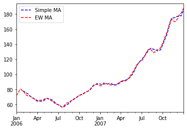

```python
plt.figure()
aapl_px = close_px.AAPL['2006':'2007']
ma60 = aapl_px.rolling(30, min_periods = 20).mean()
ewma60 = aapl_px.ewm(span = 30).mean()

ma60.plot(style = 'b--', label = 'Simple MA')
ewma60.plot(style = 'r--', label = 'EW MA')
plt.legend()
```

### 이진 이동창 함수

- 상관관계와 공분산 같은 몇몇 통계 연산은 두 개의 시계열을 필요
- 6개월간 spx지수와 AAPL 수익 상관관계

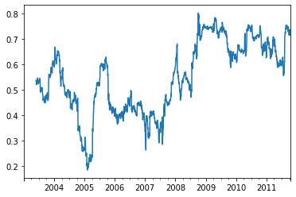

```python
plt.figure()
spx_px = close_px_all['SPX']
spx_rets = spx_px.pct_change()
returns = close_px.pct_change()

corr = returns.AAPL.rolling(125, min_periods = 100).corr(spx_rets)
corr.plot()
plt.show()
```

- 여러 주식과 spx지수와의 상관관계를 한번에 계산

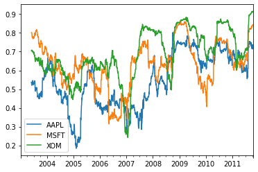

```python
plt.figure()
corr = returns.rolling(125, min_periods = 100).corr(spx_rets)
corr.plot()
plt.show()
```

### 사용자 정의 이동창 함수

```python
from scipy.stats import percentileofscore
```

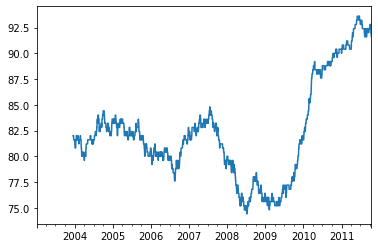

```python
plt.figure()
score_at_2percent = lambda x : percentileofscore(x, 0.02)
result = returns.AAPL.rolling(250).apply(score_at_2percent)
result.plot()
plt.show()
```